# Classification iiiA

Keyon Hedayati

4/22/2022

Load Packages

```r
library(tidyverse)
library(caret)
```

```r
library(coefplot)
```

Load the data:

```r
df_all <- readr::read_csv("final_project_train.csv", col_names = TRUE)
```

Clean the data for classification:

```r
dfiiiA <- df_all %>%
  mutate(y = ifelse(outcome == 'event', 1, 0)) %>%
  select(region, customer, starts_with('x'), y)

dfiiiA %>% glimpse()
```

```
## Rows: 677
## Columns: 36
## $ region   <chr> "XX", "XX", "XX", "XX", "XX", "XX", "XX", "XX", "XX", "XX", "…
## $ customer <chr> "B", "B", "B", "B", "B", "B", "B", "B", "B", "B", "B", "B", "…
## $ xb_01    <dbl> 4.000000, 1.000000, 2.000000, 2.520000, 2.548387, 3.071429, 3…
## $ xb_02    <dbl> 4, 1, 2, 11, 6, 6, 10, 12, 9, 10, 8, 10, 10, 8, 6, 10, 13, 10…
## $ xb_03    <dbl> 4, 1, 2, -6, -1, 1, -4, -4, -2, -4, -2, -2, -2, -4, 1, -4, -3…
## $ xn_01    <dbl> 3.0000000, 2.0000000, 2.0000000, 1.5333333, 0.8387097, 1.8571…
## $ xn_02    <dbl> 3, 2, 4, 9, 3, 8, 6, 10, 10, 4, 6, 8, 9, 5, 7, 12, 12, 6, 6, …
## $ xn_03    <dbl> 3, 2, 0, -3, -4, -2, -5, -6, -3, -5, -3, -6, -4, -3, 0, -5, -…
## $ xa_01    <dbl> 12.000000, 3.000000, 9.000000, 7.080000, 6.451613, 6.857143, …
## $ xa_02    <dbl> 12, 3, 9, 29, 17, 18, 24, 27, 20, 19, 15, 24, 24, 15, 14, 26,…
## $ xa_03    <dbl> 12, 3, 9, -7, -2, 2, -9, -5, -3, -3, -1, 1, -2, -3, 3, -4, -5…
## $ xb_04    <dbl> 1.3333333, 1.0000000, 1.0000000, 0.8950476, 1.2247312, 1.1857…
## $ xb_05    <dbl> 1.3333333, 1.0000000, 1.0000000, -2.0000000, -0.5000000, 0.00…
```

[output cut: 23 more lines]

Categorical only, additive

```r
set.seed(888)
glm_cat_add <- glm(y ~ region + customer, family = "binomial", data = dfiiiA)
glm_cat_add %>% summary()
```

```
##
## Call:
## glm(formula = y ~ region + customer, family = "binomial", data = dfiiiA)
##
## Deviance Residuals:
##     Min       1Q   Median       3Q      Max
## -1.0108  -0.6965  -0.5770  -0.3161   2.5895
##
## Coefficients:
##               Estimate Std. Error z value Pr(>|z|)
## (Intercept)    0.02713    0.50238   0.054 0.956932
## regionYY      -0.45354    0.29127  -1.557 0.119447
## regionZZ      -1.30342    0.38184  -3.414 0.000641 ***
## customerB     -1.86559    0.66084  -2.823 0.004757 **
## customerD     -2.54471    0.88418  -2.878 0.004001 **
## customerE     -3.34438    1.13070  -2.958 0.003099 **
## customerG     -0.43246    0.42394  -1.020 0.307683
## customerK     -0.61078    0.58042  -1.052 0.292665
## customerM     -0.12770    0.44222  -0.289 0.772758
## customerOther -0.86637    0.50231  -1.725 0.084567 .
## customerQ     -0.67220    0.66266  -1.014 0.310394
## ---
## Signif. codes:  0 '***' 0.001 '**' 0.01 '*' 0.05 '.' 0.1 ' ' 1
##
## (Dispersion parameter for binomial family taken to be 1)
##
##     Null deviance: 653.59  on 676  degrees of freedom
## Residual deviance: 621.74  on 666  degrees of freedom
## AIC: 643.74
##
## Number of Fisher Scoring iterations: 6
```

Continuous only, additive

```r
set.seed(888)
glm_cont_add <- glm(y ~ (. -customer -region), family = "binomial", dfiiiA)
glm_cont_add %>% summary()
```

```
##
## Call:
## glm(formula = y ~ (. - customer - region), family = "binomial",
##     data = dfiiiA)
##
## Deviance Residuals:
##      Min        1Q    Median        3Q       Max
## -2.29122  -0.54178  -0.25432  -0.04411   2.53568
##
## Coefficients:
##             Estimate Std. Error z value Pr(>|z|)
## (Intercept) -1.74664    0.83452  -2.093  0.03635 *
## xb_01        0.23535    0.33484   0.703  0.48213
## xb_02       -0.06593    0.12905  -0.511  0.60943
## xb_03       -0.02335    0.20140  -0.116  0.90770
## xn_01       -0.25124    0.39183  -0.641  0.52140
## xn_02       -0.21489    0.15341  -1.401  0.16130
## xn_03       -0.37185    0.16961  -2.192  0.02835 *
## xa_01       -0.30987    0.17743  -1.746  0.08074 .
## xa_02        0.04805    0.06648   0.723  0.46984
## xa_03        0.02498    0.11263   0.222  0.82445
## xb_04        0.46985    1.21480   0.387  0.69892
## xb_05        0.48612    0.48901   0.994  0.32018
## xb_06       -0.34854    0.27853  -1.251  0.21080
## xb_07       -0.87367    0.51166  -1.708  0.08773 .
## xb_08       -0.15574    0.52919  -0.294  0.76853
## xn_04        2.15908    1.28253   1.683  0.09229 .
## xn_05       -0.72395    0.39263  -1.844  0.06521 .
## xn_06       -0.38584    0.28749  -1.342  0.17955
## xn_07       -1.02626    0.48923  -2.098  0.03593 *
## xn_08       -0.90325    0.45462  -1.987  0.04694 *
## xa_04        0.92562    0.64324   1.439  0.15015
## xa_05       -0.42427    0.21961  -1.932  0.05337 .
## xa_06       -0.02034    0.11627  -0.175  0.86114
## xa_07        0.18466    0.29681   0.622  0.53385
## xa_08       -0.30580    0.29036  -1.053  0.29227
## xw_01       -0.03307    0.02655  -1.245  0.21304
## xw_02       -0.01233    0.01456  -0.847  0.39725
## xw_03        0.04307    0.01537   2.802  0.00509 **
## xs_01       -0.45776    2.53394  -0.181  0.85664
## xs_02        1.92673    1.38234   1.394  0.16337
## xs_03       -1.69319    1.12978  -1.499  0.13395
## xs_04        2.38492    3.72792   0.640  0.52234
## xs_05       -0.08946    2.69624  -0.033  0.97353
## xs_06        0.34687    1.37884   0.252  0.80138
## ---
## Signif. codes:  0 '***' 0.001 '**' 0.01 '*' 0.05 '.' 0.1 ' ' 1
##
## (Dispersion parameter for binomial family taken to be 1)
##
##     Null deviance: 653.59  on 676  degrees of freedom
## Residual deviance: 428.46  on 643  degrees of freedom
## AIC: 496.46
##
## Number of Fisher Scoring iterations: 7
```

All categorical and continuous linear additive

```r
glm_all_add <- glm(y ~ ., family = "binomial", data = dfiiiA)
glm_all_add %>% summary()
```

```
##
## Call:
## glm(formula = y ~ ., family = "binomial", data = dfiiiA)
##
## Deviance Residuals:
##      Min        1Q    Median        3Q       Max
## -2.51713  -0.48775  -0.19193  -0.02986   2.72956
##
## Coefficients:
##                Estimate Std. Error z value Pr(>|z|)
## (Intercept)    0.079176   1.040892   0.076  0.93937
## regionYY      -0.459934   0.382696  -1.202  0.22943
## regionZZ      -1.585516   0.493926  -3.210  0.00133 **
## customerB     -2.420042   0.858364  -2.819  0.00481 **
## customerD     -3.626300   1.118994  -3.241  0.00119 **
## customerE     -4.070174   1.305794  -3.117  0.00183 **
## customerG     -0.799423   0.597087  -1.339  0.18061
## customerK     -1.340608   0.751047  -1.785  0.07426 .
## customerM     -0.172952   0.635200  -0.272  0.78541
## customerOther -1.533744   0.659114  -2.327  0.01997 *
## customerQ     -1.958051   0.915096  -2.140  0.03238 *
## xb_01          0.191744   0.353659   0.542  0.58770
## xb_02          0.018087   0.134240   0.135  0.89282
## xb_03         -0.042694   0.211803  -0.202  0.84025
## xn_01         -0.341512   0.399361  -0.855  0.39247
## xn_02         -0.188469   0.154751  -1.218  0.22327
## xn_03         -0.399131   0.177306  -2.251  0.02438 *
## xa_01         -0.364592   0.190021  -1.919  0.05502 .
## xa_02          0.028789   0.071942   0.400  0.68903
## xa_03          0.033717   0.117716   0.286  0.77455
## xb_04          0.098036   1.291060   0.076  0.93947
## xb_05          0.652151   0.513553   1.270  0.20413
## xb_06         -0.302941   0.298214  -1.016  0.30970
## xb_07         -0.825085   0.528613  -1.561  0.11856
## xb_08         -0.073412   0.550694  -0.133  0.89395
## xn_04          2.432393   1.318686   1.845  0.06510 .
## xn_05         -0.633605   0.415522  -1.525  0.12730
## xn_06         -0.271087   0.301647  -0.899  0.36882
## xn_07         -1.278058   0.508250  -2.515  0.01192 *
## xn_08         -1.093718   0.470628  -2.324  0.02013 *
```

[output cut: 9 more lines]

```
## xs_02          2.108231   1.484366   1.420  0.15552
## xs_03         -1.639712   1.201712  -1.364  0.17242
## xs_04          2.399347   4.102694   0.585  0.55867
## xs_05         -0.370962   2.996362  -0.124  0.90147
## xs_06          0.832273   1.509090   0.552  0.58129
## ---
## Signif. codes:  0 '***' 0.001 '**' 0.01 '*' 0.05 '.' 0.1 ' ' 1
##
## (Dispersion parameter for binomial family taken to be 1)
##
##     Null deviance: 653.59  on 676  degrees of freedom
## Residual deviance: 400.78  on 633  degrees of freedom
## AIC: 488.78
##
## Number of Fisher Scoring iterations: 7
```

```r
glm_all_add %>% readr::write_rds('glm_all_additive.rds')
```

Interaction between region and continuous, w/o customer

```r
set.seed(888)
glm_cont_x_region <- glm(y ~ (region) * (. -customer), family = "binomial", data = dfiiiA)
glm_cont_x_region %>% summary()
```

```
##
## Call:
## glm(formula = y ~ (region) * (. - customer), family = "binomial",
##     data = dfiiiA)
##
## Deviance Residuals:
##      Min        1Q    Median        3Q       Max
## -2.42492  -0.46954  -0.15601  -0.01527   2.64514
##
## Coefficients:
##                  Estimate Std. Error z value Pr(>|z|)
## (Intercept)    -1.388e+00  2.451e+00  -0.566   0.5712
## regionYY       -1.811e+00  3.424e+00  -0.529   0.5968
## regionZZ       -6.515e-01  2.798e+00  -0.233   0.8159
## xb_01           7.220e-01  8.480e-01   0.851   0.3945
## xb_02          -2.640e-01  2.281e-01  -1.157   0.2473
## xb_03          -3.318e-01  4.369e-01  -0.760   0.4475
## xn_01          -6.390e-01  8.192e-01  -0.780   0.4354
## xn_02          -1.696e-01  2.635e-01  -0.644   0.5197
## xn_03          -6.944e-01  3.751e-01  -1.852   0.0641 .
## xa_01          -5.801e-01  3.911e-01  -1.483   0.1379
## xa_02           1.121e-01  1.246e-01   0.900   0.3682
## xa_03           3.656e-01  2.180e-01   1.677   0.0935 .
## xb_04          -1.796e+00  3.580e+00  -0.502   0.6158
## xb_05           1.016e+00  8.993e-01   1.130   0.2585
## xb_06          -1.655e-01  5.704e-01  -0.290   0.7717
## xb_07           4.587e-01  1.584e+00   0.290   0.7722
## xb_08           9.916e-01  1.616e+00   0.614   0.5394
## xn_04           3.565e+00  3.230e+00   1.104   0.2696
## xn_05          -6.373e-01  6.976e-01  -0.914   0.3609
## xn_06          -1.528e+00  8.126e-01  -1.880   0.0601 .
## xn_07          -8.640e-01  1.253e+00  -0.690   0.4905
## xn_08          -2.140e-01  1.299e+00  -0.165   0.8692
## xa_04          -4.389e-01  1.947e+00  -0.225   0.8217
## xa_05          -7.861e-01  3.914e-01  -2.008   0.0446 *
## xa_06          -7.567e-02  2.371e-01  -0.319   0.7496
## xa_07           7.180e-01  9.279e-01   0.774   0.4391
## xa_08           6.145e-01  9.862e-01   0.623   0.5333
## xw_01          -6.517e-02  4.895e-02  -1.331   0.1830
## xw_02           1.602e-04  2.763e-02   0.006   0.9954
```

[output cut: 68 more lines]

```
## regionZZ:xs_04 -2.116e+01  1.403e+01  -1.508   0.1314
## regionYY:xs_05  9.805e+00  8.560e+00   1.145   0.2520
## regionZZ:xs_05  1.825e+01  9.859e+00   1.851   0.0642 .
## regionYY:xs_06 -4.803e+00  3.705e+00  -1.297   0.1948
## regionZZ:xs_06  2.749e+00  5.428e+00   0.506   0.6125
## ---
## Signif. codes:  0 '***' 0.001 '**' 0.01 '*' 0.05 '.' 0.1 ' ' 1
##
## (Dispersion parameter for binomial family taken to be 1)
##
##     Null deviance: 653.59  on 676  degrees of freedom
## Residual deviance: 371.50  on 575  degrees of freedom
## AIC: 575.5
##
## Number of Fisher Scoring iterations: 7
```

Interaction between customer and continuous, w/o region

```r
set.seed(888)
glm_cont_x_cust <- glm(y ~ (customer) * (. -region), family = "binomial", data = dfiiiA)
glm_cont_x_cust %>% summary()
```

```
##
## Call:
## glm(formula = y ~ (customer) * (. - region), family = "binomial",
##     data = dfiiiA)
##
## Deviance Residuals:
##    Min      1Q  Median      3Q     Max
##  -8.49    0.00    0.00    0.00    8.49
##
## Coefficients: (6 not defined because of singularities)
##                       Estimate Std. Error    z value Pr(>|z|)
## (Intercept)         -2.873e+15  5.176e+07  -55510023   <2e-16 ***
## customerB            1.718e+16  2.094e+08   82052112   <2e-16 ***
## customerD           -3.080e+15  6.479e+08   -4753604   <2e-16 ***
## customerE            3.550e+16  1.075e+09   33025058   <2e-16 ***
## customerG            3.843e+15  6.505e+07   59073669   <2e-16 ***
## customerK           -7.659e+14  1.980e+08   -3867301   <2e-16 ***
## customerM            2.699e+15  7.965e+07   33884779   <2e-16 ***
## customerOther        1.857e+15  5.980e+07   31046484   <2e-16 ***
## customerQ           -1.886e+15  1.667e+08  -11309219   <2e-16 ***
## xb_01                6.465e+16  1.767e+09   36587599   <2e-16 ***
## xb_02               -3.754e+16  9.671e+08  -38817408   <2e-16 ***
## xb_03               -2.701e+16  8.129e+08  -33223311   <2e-16 ***
## xn_01               -2.022e+16  1.344e+09  -15039684   <2e-16 ***
## xn_02                8.051e+15  6.927e+08   11621519   <2e-16 ***
## xn_03                1.149e+16  6.638e+08   17304903   <2e-16 ***
## xa_01               -2.283e+16  6.236e+08  -36607364   <2e-16 ***
## xa_02                1.332e+16  3.151e+08   42279337   <2e-16 ***
## xa_03                9.361e+15  3.195e+08   29296390   <2e-16 ***
## xb_04                3.747e+17  8.435e+09   44425707   <2e-16 ***
## xb_05               -1.868e+17  4.357e+09  -42869132   <2e-16 ***
## xb_06               -1.894e+17  4.087e+09  -46352556   <2e-16 ***
## xb_07               -8.226e+14  2.516e+07  -32697376   <2e-16 ***
## xb_08               -2.494e+14  3.282e+07   -7598437   <2e-16 ***
## xn_04               -1.629e+17  4.735e+09  -34393525   <2e-16 ***
## xn_05                7.987e+16  2.250e+09   35504415   <2e-16 ***
## xn_06                8.275e+16  2.486e+09   33280836   <2e-16 ***
## xn_07                1.923e+14  2.007e+07    9581378   <2e-16 ***
## xn_08                5.679e+13  2.351e+07    2415465   <2e-16 ***
## xa_04                2.546e+16  1.190e+09   21387217   <2e-16 ***
```

[output cut: 272 more lines]

```
## customerG:xs_06      4.466e+16  8.447e+08   52869310   <2e-16 ***
## customerK:xs_06      2.742e+14  1.075e+09     254989   <2e-16 ***
## customerM:xs_06      3.140e+16  8.656e+08   36270077   <2e-16 ***
## customerOther:xs_06  3.381e+16  8.293e+08   40768858   <2e-16 ***
## customerQ:xs_06             NA         NA         NA       NA
## ---
## Signif. codes:  0 '***' 0.001 '**' 0.01 '*' 0.05 '.' 0.1 ' ' 1
##
## (Dispersion parameter for binomial family taken to be 1)
##
##     Null deviance:  653.59  on 676  degrees of freedom
## Residual deviance: 4685.67  on 377  degrees of freedom
## AIC: 5285.7
##
## Number of Fisher Scoring iterations: 18
```

All pairwise interactions, no categorical

```r
set.seed(888)
glm_all_pairs_cont <- glm(y ~ (. -customer -region)^2, family = "binomial", data = dfiiiA)
glm_all_pairs_cont %>% summary()
```

```
##
## Call:
## glm(formula = y ~ (. - customer - region)^2, family = "binomial",
##     data = dfiiiA)
##
## Deviance Residuals:
##        Min          1Q      Median          3Q         Max
## -1.095e-05  -2.918e-06  -2.104e-06  -2.110e-08   1.331e-05
##
## Coefficients:
##               Estimate Std. Error z value Pr(>|z|)
## (Intercept) -7.330e+01  1.309e+06       0        1
## xb_01        8.904e+01  5.882e+06       0        1
## xb_02       -4.294e+01  2.720e+06       0        1
## xb_03       -7.431e+01  4.290e+06       0        1
## xn_01        4.165e+02  8.432e+06       0        1
## xn_02       -7.130e+01  4.043e+06       0        1
## xn_03       -3.459e+02  5.317e+06       0        1
## xa_01       -4.145e+01  2.348e+06       0        1
## xa_02        1.591e+01  1.240e+06       0        1
## xa_03        1.649e+01  1.540e+06       0        1
## xb_04        7.940e+02  1.272e+07       0        1
## xb_05       -3.098e+02  7.913e+06       0        1
## xb_06       -2.697e+02  7.653e+06       0        1
## xb_07       -3.373e+01  2.034e+06       0        1
## xb_08       -1.168e+02  1.726e+06       0        1
## xn_04        2.751e+02  2.068e+07       0        1
## xn_05        2.095e+02  1.262e+07       0        1
## xn_06       -2.979e+02  9.098e+06       0        1
## xn_07       -1.217e+02  1.140e+06       0        1
## xn_08       -7.203e+01  9.270e+05       0        1
## xa_04       -7.094e+01  8.665e+06       0        1
## xa_05        2.077e+02  6.405e+06       0        1
## xa_06       -3.446e+01  3.752e+06       0        1
## xa_07       -4.551e+01  1.030e+06       0        1
## xa_08       -4.317e+01  1.020e+06       0        1
## xw_01       -7.328e+00  4.953e+05       0        1
## xw_02        3.292e+00  2.703e+05       0        1
## xw_03        5.550e+00  2.518e+05       0        1
## xs_01       -1.327e+03  5.529e+07       0        1
```

[output cut: 526 more lines]

```
## xs_02:xs_06  1.740e+02  2.048e+07       0        1
## xs_03:xs_04  3.383e+03  8.509e+07       0        1
## xs_03:xs_05 -1.525e+03  5.823e+07       0        1
## xs_03:xs_06 -7.414e+02  1.264e+07       0        1
## xs_04:xs_05  2.452e+03  3.358e+07       0        1
## xs_04:xs_06 -1.335e+03  1.793e+07       0        1
## xs_05:xs_06 -9.838e+02  3.518e+07       0        1
##
## (Dispersion parameter for binomial family taken to be 1)
##
##     Null deviance: 6.5359e+02  on 676  degrees of freedom
## Residual deviance: 7.0071e-09  on 115  degrees of freedom
## AIC: 1124
##
## Number of Fisher Scoring iterations: 25
```

Choice #1

```r
set.seed(888)
glm_region_X_spline <- glm( y ~ (. -customer) +
                    (region  *
                     splines::ns(xa_02, df = 2) +
                     splines::ns(xb_02, df = 2) +
                     splines::ns(xb_05, df = 2) +
                     splines::ns(xn_02, df = 2) +
                     splines::ns(xw_02, df = 2) +
                     splines::ns(xw_03, df = 2) +
                     splines::ns(xs_02, df = 2) +
                     splines::ns(xs_03, df = 2) +
                     splines::ns(xs_05, df = 2) +
                     splines::ns(xs_06, df = 2)),
                    family = "binomial",
                    data = dfiiiA)

glm_region_X_spline %>% summary()
```

```
##
## Call:
## glm(formula = y ~ (. - customer) + (region * splines::ns(xa_02,
##     df = 2) + splines::ns(xb_02, df = 2) + splines::ns(xb_05,
##     df = 2) + splines::ns(xn_02, df = 2) + splines::ns(xw_02,
##     df = 2) + splines::ns(xw_03, df = 2) + splines::ns(xs_02,
##     df = 2) + splines::ns(xs_03, df = 2) + splines::ns(xs_05,
##     df = 2) + splines::ns(xs_06, df = 2)), family = "binomial",
##     data = dfiiiA)
##
## Deviance Residuals:
##      Min        1Q    Median        3Q       Max
## -2.73369  -0.49219  -0.19545  -0.02568   2.91394
##
## Coefficients: (10 not defined because of singularities)
##                                      Estimate Std. Error z value Pr(>|z|)
## (Intercept)                          -9.05552    3.48877  -2.596  0.00944 **
## regionYY                              0.20921    1.56843   0.133  0.89389
## regionZZ                             -0.96539    1.53925  -0.627  0.53054
## xb_01                                 0.54603    0.39480   1.383  0.16665
## xb_02                                -0.11212    0.13287  -0.844  0.39878
## xb_03                                -0.05371    0.22057  -0.243  0.80762
## xn_01                                -0.55240    0.46617  -1.185  0.23603
## xn_02                                -0.29288    0.17084  -1.714  0.08646 .
## xn_03                                -0.36185    0.18903  -1.914  0.05559 .
## xa_01                                -0.57221    0.21554  -2.655  0.00793 **
## xa_02                                 0.08229    0.09885   0.832  0.40517
## xa_03                                 0.14057    0.12692   1.108  0.26807
## xb_04                                -0.11720    1.41281  -0.083  0.93389
## xb_05                                 0.84945    0.77609   1.095  0.27373
## xb_06                                -0.35144    0.30092  -1.168  0.24285
## xb_07                                -0.68957    0.54846  -1.257  0.20865
## xb_08                                -0.03095    0.56340  -0.055  0.95620
## xn_04                                 1.47278    1.36875   1.076  0.28193
## xn_05                                -0.48575    0.42683  -1.138  0.25511
## xn_06                                -0.35692    0.31337  -1.139  0.25472
## xn_07                                -0.86187    0.51125  -1.686  0.09183 .
## xn_08                                -0.81176    0.47100  -1.723  0.08480 .
## xa_04                                 1.09762    0.69535   1.579  0.11445
## xa_05                                -0.54979    0.24963  -2.202  0.02764 *
```

[output cut: 31 more lines]

```
## splines::ns(xs_06, df = 2)2                NA         NA      NA       NA
## regionYY:splines::ns(xa_02, df = 2)1 -1.42109    2.95724  -0.481  0.63084
## regionZZ:splines::ns(xa_02, df = 2)1 -1.52655    3.10712  -0.491  0.62321
## regionYY:splines::ns(xa_02, df = 2)2 -0.09953    2.93944  -0.034  0.97299
## regionZZ:splines::ns(xa_02, df = 2)2 -6.50470    5.25411  -1.238  0.21571
## ---
## Signif. codes:  0 '***' 0.001 '**' 0.01 '*' 0.05 '.' 0.1 ' ' 1
##
## (Dispersion parameter for binomial family taken to be 1)
##
##     Null deviance: 653.59  on 676  degrees of freedom
## Residual deviance: 403.11  on 627  degrees of freedom
## AIC: 503.11
##
## Number of Fisher Scoring iterations: 7
```

Choice # 2

```r
set.seed(888)
glm_region_X_pairs <- glm( y ~ region * (. -customer)^2,
                            family = "binomial",
                    data = dfiiiA)
glm_region_X_pairs %>% summary()
```

```
##
## Call:
## glm(formula = y ~ region * (. - customer)^2, family = "binomial",
##     data = dfiiiA)
##
## Deviance Residuals:
##    Min      1Q  Median      3Q     Max
##  -8.49    0.00    0.00    0.00    8.49
##
## Coefficients: (1026 not defined because of singularities)
##                        Estimate Std. Error    z value Pr(>|z|)
## (Intercept)           8.244e+22  5.527e+19  1.492e+03  < 2e-16 ***
## regionYY             -5.595e+22  2.025e+20 -2.764e+02  < 2e-16 ***
## regionZZ             -8.244e+22  5.527e+19 -1.492e+03  < 2e-16 ***
## xb_01                -1.196e+24  2.560e+21 -4.671e+02  < 2e-16 ***
## xb_02                 1.192e+24  7.848e+20  1.519e+03  < 2e-16 ***
## xb_03                 1.175e+23  1.796e+21  6.541e+01  < 2e-16 ***
## xn_01                 4.802e+23  3.813e+21  1.259e+02  < 2e-16 ***
## xn_02                -2.055e+23  1.134e+21 -1.813e+02  < 2e-16 ***
## xn_03                -3.625e+23  2.772e+21 -1.308e+02  < 2e-16 ***
## xa_01                 8.878e+23  1.383e+21  6.418e+02  < 2e-16 ***
## xa_02                -6.595e+23  5.816e+20 -1.134e+03  < 2e-16 ***
## xa_03                -1.932e+23  8.636e+20 -2.237e+02  < 2e-16 ***
## xb_04                -7.778e+23  1.109e+22 -7.011e+01  < 2e-16 ***
## xb_05                 3.253e+23  7.746e+21  4.199e+01  < 2e-16 ***
## xb_06                -5.914e+23  4.250e+21 -1.391e+02  < 2e-16 ***
## xb_07                 3.221e+23  2.619e+20  1.230e+03  < 2e-16 ***
## xb_08                 6.213e+23  3.764e+20  1.651e+03  < 2e-16 ***
## xn_04                 2.236e+23  1.114e+22  2.008e+01  < 2e-16 ***
## xn_05                 6.607e+23  7.162e+21  9.226e+01  < 2e-16 ***
## xn_06                -7.870e+23  4.209e+21 -1.870e+02  < 2e-16 ***
## xn_07                -5.117e+22  1.159e+20 -4.416e+02  < 2e-16 ***
## xn_08                -1.688e+23  1.498e+19 -1.127e+04  < 2e-16 ***
## xa_04                -1.212e+24  3.562e+21 -3.404e+02  < 2e-16 ***
## xa_05                 7.152e+22  1.989e+21  3.596e+01  < 2e-16 ***
## xa_06                 8.032e+23  2.283e+21  3.518e+02  < 2e-16 ***
## xa_07                 1.916e+23  6.048e+18  3.168e+04  < 2e-16 ***
## xa_08                 1.465e+23  5.983e+18  2.449e+04  < 2e-16 ***
## xw_01                -8.324e+22  2.086e+20 -3.991e+02  < 2e-16 ***
## xw_02                 3.641e+22  1.200e+20  3.035e+02  < 2e-16 ***
```

[output cut: 1652 more lines]

```
## regionZZ:xs_04:xs_05         NA         NA         NA       NA
## regionYY:xs_04:xs_06         NA         NA         NA       NA
## regionZZ:xs_04:xs_06         NA         NA         NA       NA
## regionYY:xs_05:xs_06         NA         NA         NA       NA
## regionZZ:xs_05:xs_06         NA         NA         NA       NA
## ---
## Signif. codes:  0 '***' 0.001 '**' 0.01 '*' 0.05 '.' 0.1 ' ' 1
##
## (Dispersion parameter for binomial family taken to be 1)
##
##     Null deviance:   653.59  on 676  degrees of freedom
## Residual deviance: 12399.02  on  17  degrees of freedom
## AIC: 13719
##
## Number of Fisher Scoring iterations: 25
```

Choice # 3

```r
set.seed(888)
glm_cust_X_spline <- glm( y ~ (. -region) +
                    (customer  *
                     splines::ns(xn_01, df = 3) +
                     splines::ns(xb_02, df = 4) +
                     splines::ns(xb_05, df = 4) +
                     splines::ns(xn_02, df = 4) +
                     splines::ns(xw_02, df = 4) +
                     splines::ns(xw_03, df = 4) +
                     splines::ns(xs_02, df = 4) +
                     splines::ns(xs_03, df = 4) +
                     splines::ns(xs_05, df = 4) +
                     splines::ns(xs_06, df = 4)),
                    family = "binomial",
                    data = dfiiiA)
```

```
## Warning: glm.fit: fitted probabilities numerically 0 or 1 occurred
```

```r
glm_cust_X_spline %>% summary()
```

```
##
## Call:
## glm(formula = y ~ (. - region) + (customer * splines::ns(xn_01,
##     df = 3) + splines::ns(xb_02, df = 4) + splines::ns(xb_05,
##     df = 4) + splines::ns(xn_02, df = 4) + splines::ns(xw_02,
##     df = 4) + splines::ns(xw_03, df = 4) + splines::ns(xs_02,
##     df = 4) + splines::ns(xs_03, df = 4) + splines::ns(xs_05,
##     df = 4) + splines::ns(xs_06, df = 4)), family = "binomial",
##     data = dfiiiA)
##
## Deviance Residuals:
##      Min        1Q    Median        3Q       Max
## -1.95949  -0.35930  -0.03804   0.00000   2.91286
##
## Coefficients: (10 not defined because of singularities)
##                                             Estimate Std. Error z value
## (Intercept)                               -1.372e+02  2.513e+02  -0.546
## customerB                                  1.520e+02  2.475e+02   0.614
## customerD                                 -1.379e+03  4.270e+05  -0.003
## customerE                                  1.561e+03  2.867e+06   0.001
## customerG                                  3.365e+00  4.527e+00   0.743
## customerK                                 -4.537e+00  8.595e+00  -0.528
## customerM                                  3.867e+00  5.586e+00   0.692
## customerOther                              5.643e-01  2.974e+00   0.190
## customerQ                                  4.135e+00  5.630e+00   0.735
## xb_01                                      5.838e-01  5.442e-01   1.073
## xb_02                                      2.877e-02  2.013e-01   0.143
## xb_03                                     -4.170e-01  3.069e-01  -1.359
## xn_01                                     -3.198e+01  6.285e+01  -0.509
## xn_02                                     -7.661e-01  4.424e-01  -1.732
## xn_03                                     -3.987e-01  2.278e-01  -1.751
## xa_01                                     -6.178e-01  2.378e-01  -2.597
## xa_02                                      7.379e-02  8.689e-02   0.849
## xa_03                                      2.055e-01  1.506e-01   1.365
## xb_04                                     -2.418e-01  1.923e+00  -0.126
## xb_05                                      1.225e+00  1.178e+00   1.040
## xb_06                                     -3.829e-01  3.844e-01  -0.996
## xb_07                                     -1.056e+00  6.926e-01  -1.525
## xb_08                                     -3.335e-01  7.046e-01  -0.473
## xn_04                                      1.921e+00  1.772e+00   1.084
```

[output cut: 182 more lines]

```
## customerG:splines::ns(xn_01, df = 3)3      0.66348
## customerK:splines::ns(xn_01, df = 3)3      0.98790
## customerM:splines::ns(xn_01, df = 3)3      0.09952 .
## customerOther:splines::ns(xn_01, df = 3)3  0.61418
## customerQ:splines::ns(xn_01, df = 3)3      0.63694
## ---
## Signif. codes:  0 '***' 0.001 '**' 0.01 '*' 0.05 '.' 0.1 ' ' 1
##
## (Dispersion parameter for binomial family taken to be 1)
##
##     Null deviance: 653.59  on 676  degrees of freedom
## Residual deviance: 319.37  on 582  degrees of freedom
## AIC: 509.37
##
## Number of Fisher Scoring iterations: 25
```

After fitting all of the models, we definitely received some warnings such as ‘fitted probabilities numerically 0 or 1 occurred’. There is no way to predict how the probability is changing with the changing input, because it isn’t changing. There is linear separation which causes the problem, and you see it when there are low data points. It is also why we are missing some of the coefficients when printing out. The program essentially crashes.

**Performance**

```r
# pass in model to pull out relevant metrics
extract_metrics <- function(mod, mod_name)
{
  broom::glance(mod) %>% mutate(mod_name = mod_name)
}
```

```r
all_metrics <- purrr::map2_dfr(list(glm_cat_add, glm_cont_add, glm_all_add, glm_cont_x_region,
                                    glm_cont_x_cust, glm_all_pairs_cont,
                                    glm_region_X_spline, glm_region_X_pairs, glm_cust_X_spline),
                               c("glm_cat_add", "glm_cont_add", "glm_all_add", "glm_cont_x_region",
                                    "glm_cont_x_cust", "glm_all_pairs_cont",
                                    "glm_region_X_spline", "glm_region_X_pairs", "glm_cust_X_spline"),
                               extract_metrics)


all_metrics %>% glimpse()
```

```
## Rows: 9
## Columns: 9
## $ null.deviance <dbl> 653.5933, 653.5933, 653.5933, 653.5933, 653.5933, 653.59…
## $ df.null       <int> 676, 676, 676, 676, 676, 676, 676, 676, 676
## $ logLik        <dbl> -3.108701e+02, -2.142286e+02, -2.003879e+02, -1.857495e+…
## $ AIC           <dbl> 643.7403, 496.4571, 488.7758, 575.4990, 5285.6749, 1124.…
## $ BIC           <dbl> 693.4347, 650.0579, 687.5533, 1036.3015, 6640.9763, 3662…
## $ deviance      <dbl> 6.217403e+02, 4.284571e+02, 4.007758e+02, 3.714990e+02, …
## $ df.residual   <int> 666, 643, 633, 575, 377, 115, 627, 17, 582
## $ nobs          <int> 677, 677, 677, 677, 677, 677, 677, 677, 677
## $ mod_name      <chr> "glm_cat_add", "glm_cont_add", "glm_all_add", "glm_cont_…
```

Visualization

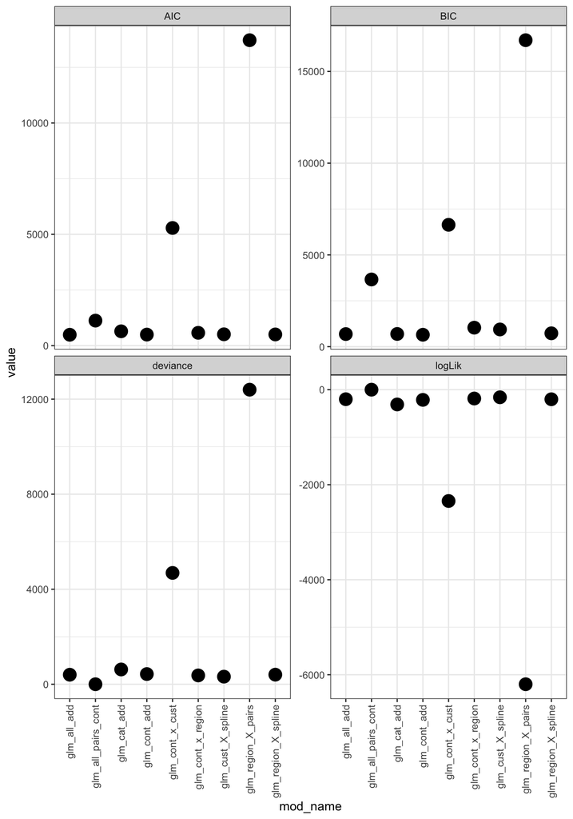

```r
all_metrics %>%
  select(mod_name, deviance, logLik, AIC, BIC) %>%
  pivot_longer(!c("mod_name")) %>%
  ggplot(mapping = aes(x = mod_name, y = value)) +
  geom_point(size = 5) +
  facet_wrap(~name, scales = "free_y") +
  theme_bw() +
  theme(axis.text.x = element_text(angle = 90, vjust = 0.5, hjust=1))
```

By the above graphic, I think the top models are: *glm_all_add*, *glm_region_X_spline*, *glm_cust_X_spline* by looking a balance of all the metrics shown above.

**Coefficient Summaries**

Now we will look at the coefficients of the top 3.

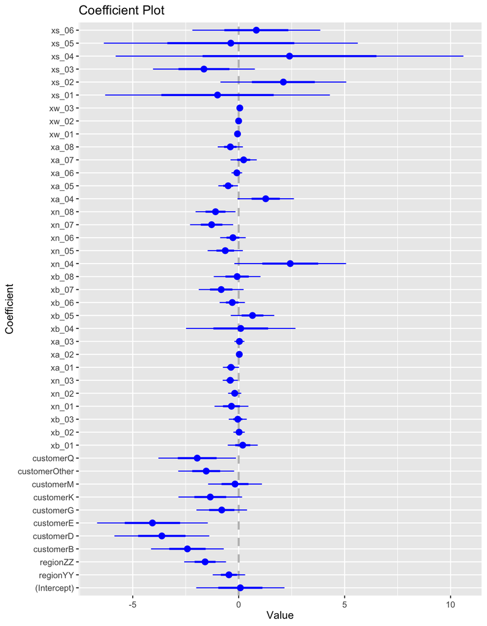

```r
coefplot(glm_all_add)
```

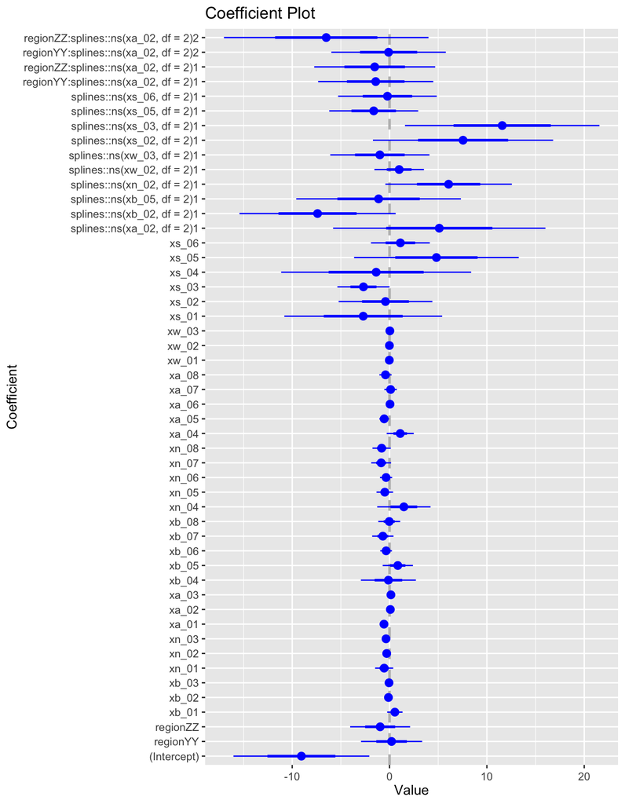

```r
coefplot(glm_region_X_spline)
```

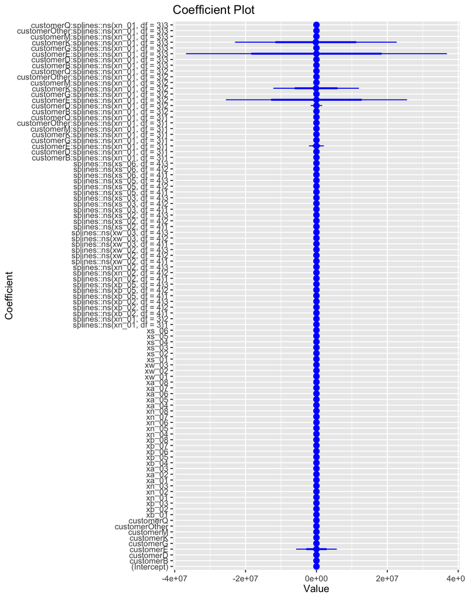

```r
coefplot(glm_cust_X_spline)
```